# Dutch election 2017

Holger Doering – University of Bremen

16 March 2017

**Election Netherlands 15 March 2017**

This morning, two facts from yesterdays Dutch election were particularly striking to me.

- The **Social Democracts** (PVdA) fell from **24.8% in 2012** to **5.7%** vote share.
- The **largest party** (Liberals, VVD) won only **21.3%** vote share.

The Economist has a [nice chart](http://www.economist.com/blogs/graphicdetail/2017/03/daily-chart-10) visualizing the results.

I wondered what these effects are in a comparative perspective and conducted an analysis with data from [ParlGov](http://www.parlgov.org/).

Here are the main facts.

1. The electoral loss of the Social Democrats (PVdA) was particularly bad.
2. A largest party with little more than 20% vote share is less exceptional nowadays.

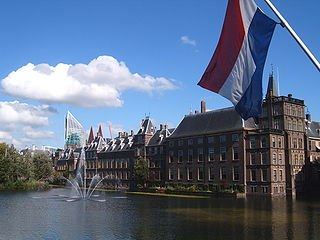

```r
library(tidyverse)
library(lubridate)

library(knitr)
options(knitr.kable.NA = '')
```

I use the data from [ParlGov](http://www.parlgov.org/) and limit my analysis to older democracies, excluding countries from Central/Eastern Europe.

```r
db_file <- 'parlgov.db'
url <- 'http://www.parlgov.org/static/data/parlgov-experimental.db'
if( ! db_file %in% list.files()) download.file(url, db_file, mode='wb')
parlgov_db <- src_sqlite(db_file)

get_decade <- function(election_date) year(election_date) %/% 10 * 10

get_parlgov_table <- function(table_name) tbl(parlgov_db, table_name) %>% as_tibble
party_raw <- get_parlgov_table('view_party')
elec_raw <- get_parlgov_table('view_election')

elec <- elec_raw %>%
  filter(election_type == 'parliament',
         election_date >= '1945-01-01') %>%
  mutate(country = country_name,
         decade = get_decade(election_date)) %>%
  left_join(party_raw %>% select(party_id, family=family_name_short)) %>%
  group_by(country) %>%
  filter(min(election_date) <= '1980-01-01') %>%
  ungroup

elec_info <- get_parlgov_table('election')
turnout <- elec_info %>%
  filter(id %in% elec$election_id) %>%
  mutate(decade = get_decade(date)) %>%
  group_by(decade) %>%
  summarize(turnout = mean(votes_valid / electorate, na.rm=T))

results <- get_parlgov_table('election_result')
alliance <- results %>%
  filter(id %in% alliance_id) %>%
  mutate(tmp = paste(election_id, party_id)) %>%
  .[['tmp']]

cabinet <- get_parlgov_table('view_cabinet')
cab_party <- cabinet %>%
  filter(cabinet_party == 1) %>%
  distinct(election_id, party_id) %>%
  mutate(cabinet = 1)
```

First, I look at the electoral performance of the Dutch Social Democrats (PVdA) with the following information.

- mean vote share PVdA by decade
- PVdA election results compared to Social Democrats in Germany and Sweden
- party family vote share by decade
- large electoral losses in old democracies

# PvdA vote share

[figure not shown]

```r
socdem <- elec %>%
  filter(party_id %in% c(558, 742, 904)) %>%  # NOR-104 SWE-904
  mutate(year = year(election_date),
         party = paste(stringi::stri_trans_totitle(country_name_short), party_name_short, sep=' - ')) %>%
  bind_rows(tibble(party='Nld - PvdA', party_name_short='PvdA',
                   decade=2010, year=2017, vote_share=5.7))

pvda <- socdem %>%
  filter(party_name_short == 'PvdA') %>%
  group_by(decade) %>%
  summarise(vote_share = round(mean(vote_share, na.rm=T), 0)) %>%
  spread(decade, vote_share)
pvda %>% kable
```

| 1940 | 1950 | 1960 | 1970 | 1980 | 1990 | 2000 | 2010 |
| --- | --- | --- | --- | --- | --- | --- | --- |
| 27 | 31 | 26 | 29 | 31 | 26 | 21 | 17 |

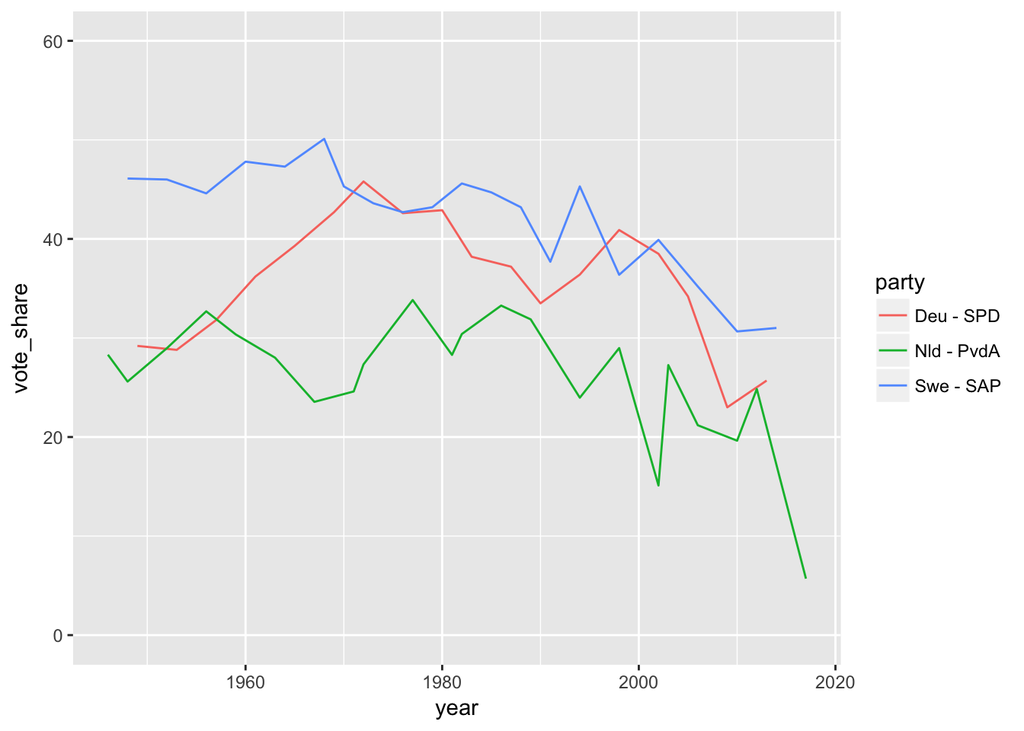

```r
ggplot(socdem, aes(year, vote_share, color=party)) + geom_line() + ylim(0, 60)
```

# Party family share

Here, I present a comparison of the mean vote share of the main party families by decade.

Nevertheless, I was surprised how relatively stable the mean vote by party family has been.

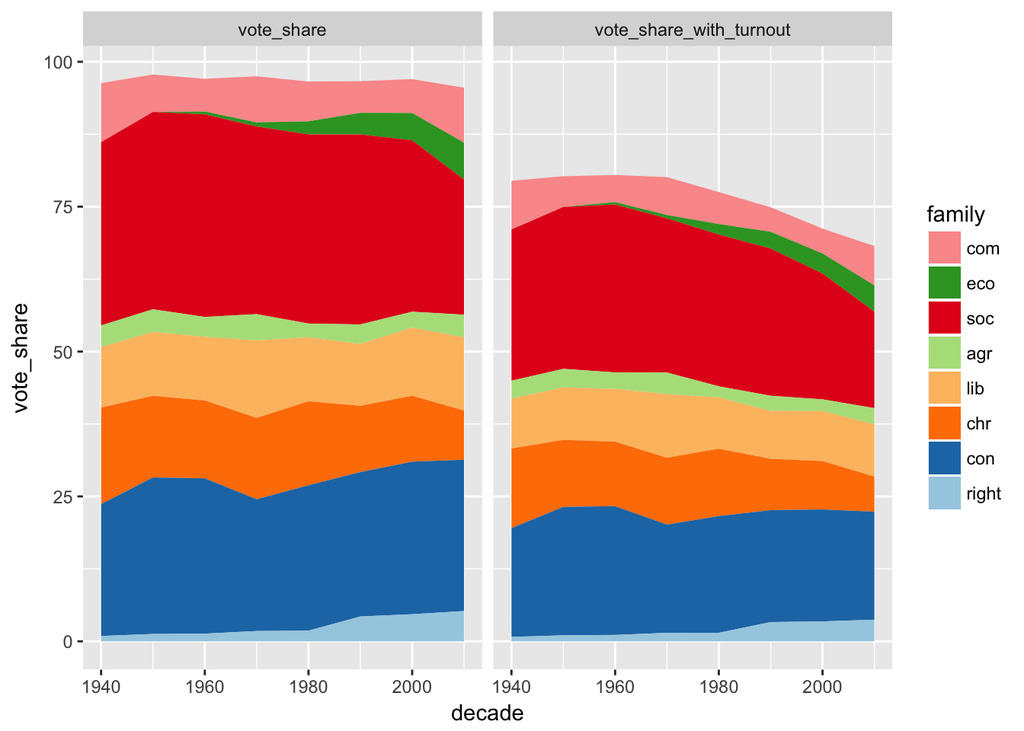

```r
pa_fam <- elec %>%
  filter( ! family %in% c('code', 'none', 'spec')) %>%
  group_by(decade, election_id, family) %>%
  summarise(vote_share = sum(vote_share, na.rm=T)) %>%
  group_by(decade, family)

# use reshape to add 0.0% for complete family data
pa_fam <-  pa_fam %>%
  spread(family, vote_share, fill = 0) %>%
  gather(family, vote_share, -election_id, -decade) %>%
  group_by(decade, family) %>%
  summarise(vote_share = mean(vote_share, na.rm=T))

fam_level <- c('com', 'eco', 'soc', 'agr', 'lib', 'chr', 'con', 'right')
fam_color <- c('#FB9A99', '#33A02C', '#E31A1C', '#B2DF8A', '#FDBF6F', '#FF7F00', '#1F78B4', '#A6CEE3')
pa_fam <- pa_fam %>% mutate(family = factor(family, fam_level))

pa_fam_pl <- pa_fam %>%
  left_join(turnout) %>%
  mutate(vote_share_with_turnout = vote_share * turnout) %>%
  select(-turnout) %>%
  gather(turnout, vote_share, -decade, -family)

ggplot(pa_fam_pl, aes(decade, vote_share, fill=family)) +
  geom_area(position = 'stack') +
  scale_fill_manual(values = fam_color) +
  facet_grid(. ~ turnout)
```

```r
pa_fam_wide <- pa_fam %>%
  mutate(vote_share = round(vote_share, 0)) %>%
  spread(decade, vote_share, fill = 0)
pa_fam_wide %>% kable
```

| family | 1940 | 1950 | 1960 | 1970 | 1980 | 1990 | 2000 | 2010 |
| --- | --- | --- | --- | --- | --- | --- | --- | --- |
| com | 10 | 6 | 6 | 8 | 7 | 5 | 6 | 9 |
| eco | 0 | 0 | 0 | 1 | 2 | 4 | 5 | 6 |
| soc | 32 | 34 | 35 | 32 | 33 | 33 | 30 | 23 |
| agr | 4 | 4 | 3 | 5 | 2 | 3 | 3 | 4 |
| lib | 10 | 11 | 11 | 13 | 11 | 11 | 12 | 13 |
| chr | 17 | 14 | 13 | 14 | 14 | 11 | 11 | 8 |
| con | 23 | 27 | 27 | 23 | 25 | 25 | 26 | 26 |
| right | 1 | 1 | 1 | 2 | 2 | 4 | 5 | 5 |

# Electoral losses

## Cost or ruling

Parties in cabinet tend to loose votes. A fact that political scientists refer to as the cost of ruling (see [Nannestad/Paldam 2002](https://books.google.de/books?hl=en&lr=&id=vdGeUywOkR0C&oi=fnd&pg=PA17&dq=Nannestad+Paldam&ots=h_OVPMvfjk&sig=xCIfGOoG2maiD8UkKeIeu11QOPU&redir_esc=y#v=onepage&q=Nannestad%20Paldam&f=false)).

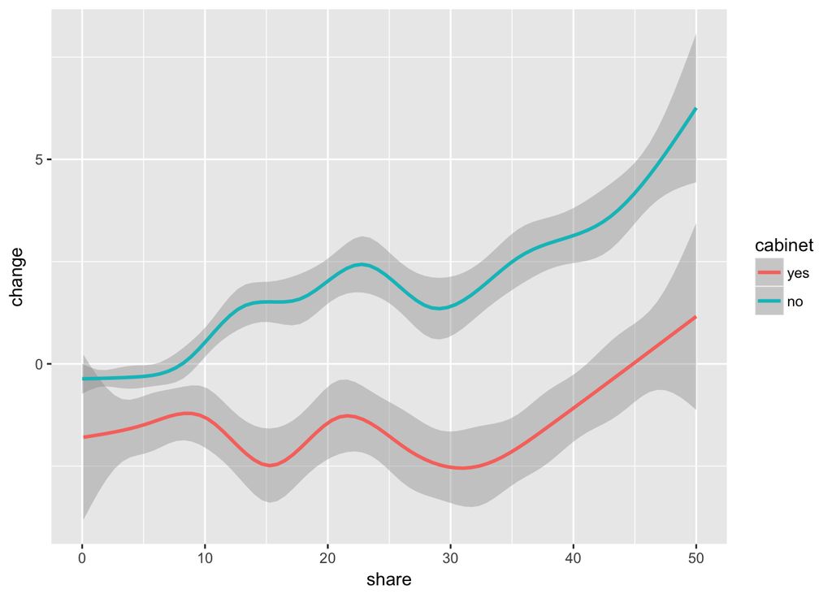

```r
elec_prev <- elec %>%
  filter( ! paste(election_id, party_id) %in% alliance) %>%
  left_join(cab_party) %>%
  mutate(cabinet = ifelse(is.na(cabinet), 'no', 'yes') %>% factor(c('yes', 'no'))) %>%
  select(country, party_id, cabinet,
         previous_parliament_election_id = election_id,
         vote_share_last = vote_share)

party_url <- '[%s](http://www.parlgov.org/explore/%s/party/%s/)'

loss <- elec %>%
  inner_join(elec_prev) %>%
  mutate(change = vote_share - vote_share_last,
         year = year(election_date),
         name = party_name_english,
         party = sprintf(party_url, party_name_short, country_name_short, party_id)) %>%
  select(country, year, cabinet, party, name, family, last=vote_share_last, share=vote_share, change) %>%
  mutate_each(funs(round(.,1)), last, share, change) %>%
  arrange(change)

ggplot(loss, aes(share, change, color=cabinet)) + geom_smooth() + xlim(c(0, 50))
```

## Largest vote losses

Here, I list the largest vote losses (excluding alliances). All of the parties were members of cabinet in the previous legislative term.

Given the modest size of the PVdA in recent elections with about 20% vote share, only [Kadima](http://www.parlgov.org/explore/ISR/party/1870/) in Israel suffered a similar electoral defeat. However, Kadima was competing with a splinter party ([Hatnuah](http://www.parlgov.org/explore/isr/party/2320/)) and the combined vote share reduces the electoral loss in comparative perspective.

```r
loss %>% top_n(-20) %>% kable
```

| country | year | cabinet | party | name | family | last | share | change |
| --- | --- | --- | --- | --- | --- | --- | --- | --- |
| Malta | 1950 | yes | [MLP](http://www.parlgov.org/explore/MLT/party/1003/) | Malta Labour Party | soc | 59.9 | 28.6 | -31.3 |
| Greece | 2012 | yes | [PASOK](http://www.parlgov.org/explore/GRC/party/1338/) | Panhellenic Socialist Movement | soc | 43.9 | 13.2 | -30.7 |
| Canada | 1993 | yes | [PCP](http://www.parlgov.org/explore/CAN/party/794/) | Progressive Conservative Party of Canada | con | 42.7 | 16.0 | -26.7 |
| Japan | 2012 | yes | [DPJ](http://www.parlgov.org/explore/JPN/party/439/) | Democratic Party of Japan | con | 42.4 | 16.0 | -26.4 |
| Ireland | 2011 | yes | [FF](http://www.parlgov.org/explore/IRL/party/280/) | Fianna Fail | con | 41.6 | 17.4 | -24.1 |
| Malta | 1962 | yes | [MLP](http://www.parlgov.org/explore/MLT/party/1003/) | Malta Labour Party | soc | 56.7 | 33.9 | -22.9 |
| Israel | 2006 | yes | [L](http://www.parlgov.org/explore/ISR/party/678/) | The Consolidation | con | 29.4 | 9.0 | -20.4 |
| Israel | 2013 | yes | [Kadima](http://www.parlgov.org/explore/ISR/party/1870/) | Forward | lib | 22.5 | 2.1 | -20.4 |
| Spain | 2011 | yes | [PSOE](http://www.parlgov.org/explore/ESP/party/902/) | Spanish Socialist Workers Party | soc | 44.4 | 25.3 | -19.0 |
| France | 1956 | yes | [G](http://www.parlgov.org/explore/FRA/party/1094/) | Gaullists | con | 21.8 | 4.0 | -17.8 |
| France | 1993 | yes | [PS](http://www.parlgov.org/explore/FRA/party/1539/) | Socialist Party | soc | 34.9 | 17.6 | -17.3 |
| Iceland | 2013 | yes | [Sam](http://www.parlgov.org/explore/ISL/party/1006/) | Social Democratic Alliance | soc | 29.8 | 12.8 | -17.0 |
| Austria | 2002 | yes | [FPO](http://www.parlgov.org/explore/AUT/party/50/) | Freedom Party of Austria | right | 26.9 | 10.0 | -16.9 |
| Portugal | 1995 | yes | [PSD](http://www.parlgov.org/explore/PRT/party/1273/) | Social Democratic Party | lib | 51.6 | 34.8 | -16.8 |
| Italy | 2013 | yes | [FI-PdL](http://www.parlgov.org/explore/ITA/party/596/) | Go Italy – The People of Freedom | con | 38.2 | 21.6 | -16.7 |
| Canada | 1962 | yes | [PCP](http://www.parlgov.org/explore/CAN/party/794/) | Progressive Conservative Party of Canada | con | 53.7 | 37.2 | -16.4 |
| Canada | 1984 | yes | [LP](http://www.parlgov.org/explore/CAN/party/368/) | Liberal Party of Canada | lib | 44.3 | 28.0 | -16.3 |
| Portugal | 1985 | yes | [PS](http://www.parlgov.org/explore/PRT/party/725/) | Socialist Party | soc | 37.1 | 21.3 | -15.8 |
| United Kingdom | 2015 | yes | [Lib](http://www.parlgov.org/explore/GBR/party/659/) | Liberals | lib | 23.0 | 7.9 | -15.1 |
| Israel | 1977 | yes | [HM\|HA](http://www.parlgov.org/explore/ISR/party/244/) | Alignment \| Labor | soc | 39.6 | 24.6 | -15.0 |

# Largest party vote share

## Smallest largest party

Recently, elections in several countries have resulted in largest parties with only about 20% vote share.

```r
elec_url <- '[%s](http://www.parlgov.org/explore/%s/election/%s/)'

elec_max <- elec %>%
  mutate(year = year(election_date)) %>%
  group_by(country, year) %>%
  mutate(share_max = round(max(vote_share, na.rm=T), 1)) %>%
  ungroup %>%
  mutate(year = sprintf(elec_url, year, country_name_short, election_date)) %>%
  arrange(share_max) %>%
  distinct(country, .keep_all=T) %>%
  select(country, year, party=party_name_short, share_max)

elec_max %>% top_n(10, -share_max) %>% kable
```

| country | year | party | share_max |
| --- | --- | --- | --- |
| Belgium | [1999](http://www.parlgov.org/explore/BEL/election/1999-06-13/) | PVV\|VLD | 14.3 |
| Israel | [1999](http://www.parlgov.org/explore/ISR/election/1999-05-17/) | HM\|HA | 20.2 |
| Finland | [2011](http://www.parlgov.org/explore/FIN/election/2011-04-17/) | KOK | 20.4 |
| France | [1993](http://www.parlgov.org/explore/FRA/election/1993-03-28/) | RPR | 20.4 |
| Netherlands | [2010](http://www.parlgov.org/explore/NLD/election/2010-06-09/) | VVD | 20.5 |
| Switzerland | [1991](http://www.parlgov.org/explore/CHE/election/1991-10-20/) | FDP-PRD | 21.0 |
| Norway | [2001](http://www.parlgov.org/explore/NOR/election/2001-09-10/) | DNA | 24.3 |
| Japan | [1946](http://www.parlgov.org/explore/JPN/election/1946-04-10/) | JLP | 25.4 |
| Ireland | [2016](http://www.parlgov.org/explore/IRL/election/2016-02-26/) | FG | 25.5 |
| Denmark | [1973](http://www.parlgov.org/explore/DNK/election/1973-12-04/) | Sd | 25.6 |
| Italy | [2013](http://www.parlgov.org/explore/ITA/election/2013-02-25/) | PD | 25.6 |

## Largest party share by decade

This is the result of a general decline in the vote share of the largest party and more fragmented party systems.

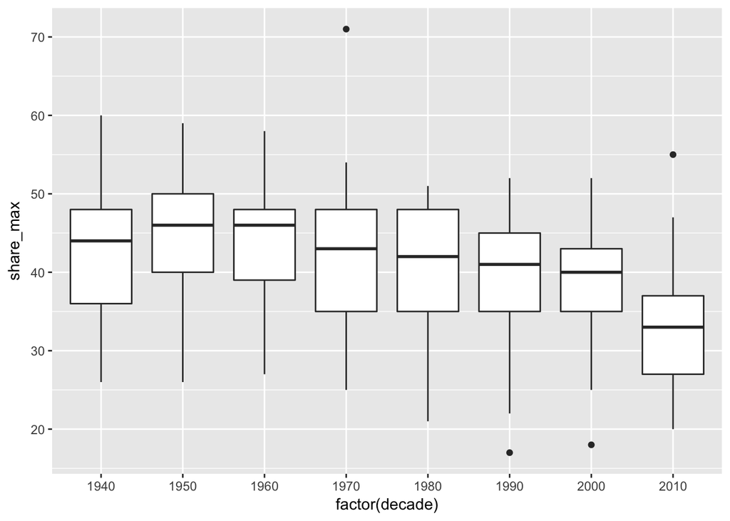

```r
decade <- elec %>%
  group_by(country, decade) %>%
  summarise(share_max = round(max(vote_share, na.rm=T), 0))

ggplot(decade, aes(factor(decade), share_max)) + geom_boxplot()
```

```r
decade_wide <- decade %>% tidyr::spread(decade, share_max)
knitr::kable(decade_wide)
```

| country | 1940 | 1950 | 1960 | 1970 | 1980 | 1990 | 2000 | 2010 |
| --- | --- | --- | --- | --- | --- | --- | --- | --- |
| Australia | 50 | 50 | 48 | 50 | 50 | 45 | 43 | 38 |
| Austria | 50 | 46 | 48 | 51 | 48 | 43 | 42 | 27 |
| Belgium | 44 | 48 | 42 | 27 | 21 | 17 | 18 | 20 |
| Canada | 50 | 54 | 46 | 43 | 50 | 41 | 41 | 40 |
| Cyprus |  |  |  | 71 | 34 | 36 | 35 | 34 |
| Denmark | 40 | 41 | 42 | 38 | 33 | 37 | 31 | 26 |
| Finland | 26 | 26 | 27 | 26 | 27 | 28 | 25 | 21 |
| France | 29 | 27 | 38 | 26 | 36 | 24 | 40 | 29 |
| Germany | 29 | 40 | 43 | 46 | 43 | 41 | 38 | 34 |
| Greece |  |  |  | 54 | 48 | 47 | 45 | 36 |
| Iceland | 40 | 42 | 41 | 43 | 39 | 41 | 37 | 28 |
| Ireland | 42 | 48 | 48 | 51 | 47 | 39 | 42 | 36 |
| Israel | 36 | 38 | 46 | 40 | 37 | 35 | 29 | 23 |
| Italy | 48 | 42 | 39 | 39 | 34 | 46 | 46 | 26 |
| Japan | 44 | 59 | 58 | 47 | 49 | 46 | 42 | 33 |
| Luxembourg | 41 | 42 | 38 | 35 | 35 | 30 | 38 | 34 |
| Malta | 60 | 57 | 48 | 52 | 51 | 52 | 52 | 55 |
| Netherlands | 31 | 33 | 32 | 34 | 35 | 29 | 29 | 27 |
| New Zealand | 52 | 54 | 48 | 48 | 48 | 48 | 45 | 47 |
| Norway | 46 | 48 | 47 | 42 | 41 | 37 | 35 | 31 |
| Portugal |  |  |  | 44 | 51 | 52 | 46 | 40 |
| Spain |  |  |  | 35 | 48 | 39 | 45 | 42 |
| Sweden | 46 | 46 | 50 | 45 | 46 | 45 | 40 | 31 |
| Switzerland | 26 | 27 | 27 | 25 | 23 | 22 | 29 | 29 |
| United Kingdom | 48 | 50 | 48 | 46 | 42 | 43 | 41 | 37 |

# Sources

Analysis in R with `tidyverse` and document created in `knitr`.

Images linked to from [Wikimedia Commons](https://commons.wikimedia.org/wiki/Main_Page).

# Updates

Initial analysis on 16 March 2017.

Minor updates afterwards:

- added cabinet status to vote share loss
- added turnout to party family vote share plot
- switched colors of liberals and right party families

Last updated on 17 March 2017, 10:34